# An Introduction to hpgltools Usage

### Streptococcus initial visualization

In contrast, something strange is going on with the pyogenes data.

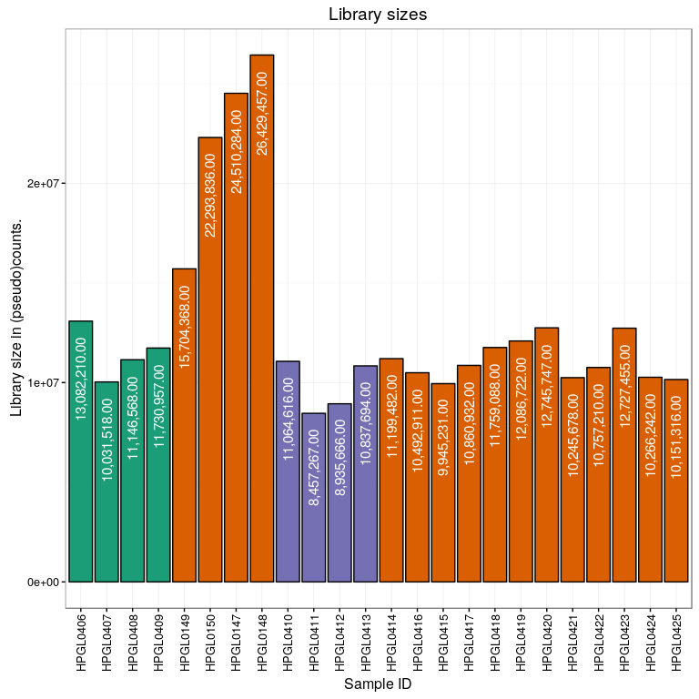

```r
print(sp_metrics$libsize)
```

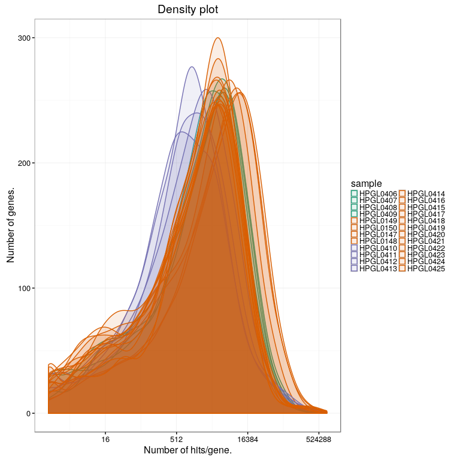

```r
## 4 libraries are rather larger than the others

print(sp_metrics$density)
```

```r
## The densities are a bit concerning
```

# Normalizing and re-graphing

There are more than a few different things one may do to normalize the data including:

1. Remove low-count genes
- genefilter’s pv, cv, pofa functions
- threshold based filtering from cbcb
2. Normalize counts to dull the effect of outliers
- DESeq sizefactoring, variance stabilization
- quantile normalization with normalize.quantiles or cbcb’s qsmooth
- edgeR’s TMM normalization, upperquartile, or RLE
3. Convert the resulting data to CPM/RPKM/etc
- edgeR’s cpm/rpkm
- cp_SEQ_m using instances of arbitrary patterns
4. Minimize batch effects
- cbcb’s batch removal
- limma’s removeBatchEffect()
- sva’s combat/sva/ssva/fsva
- RUV’s RUVg
5. Transform the data to a log scale for easier visualization
- Can try log2/log10/ln

## Normalization methods

If no arguments are passed to normalize_expt(), then it will leave the data alone. For each of the 5 sections above, there is an option, as illustrated in the next block.

```r
hs_norm <- normalize_expt(hs_inf_lp_sub, filter_low=TRUE, norm="quant", convert="cpm", transform="log2", batch="combat")
```

```
## This function will replace the expt$expressionset slot with:
```

```
## log2(batch-correct(cpm(quant(low-filter(data)))))
```

```
## It backs up the current data into a slot named:
##  expt$backup_expressionset. It will also save copies of each step along the way
##  in expt$normalized with the corresponding libsizes. Keep the libsizes in mind
##  when invoking limma.  The appropriate libsize is the non-log(cpm(normalized)).
##  This is most likely kept at:
##  'new_expt$normalized$intermediate_counts$normalization$libsizes'
##  A copy of this may also be found at:
##  new_expt$best_libsize
```

```
## Performing low-count filter with option: TRUE
```

```
## Removing 30485 low-count genes (20556 remaining).
```

```
## batch_counts: Before batch correction, 76083 entries 0<x<1.
```

```
## batch_counts: Using sva::combat with a prior for batch correction.
```

```
## Found 2 batches
## Adjusting for 1 covariate(s) or covariate level(s)
## Standardizing Data across genes
## Fitting L/S model and finding priors
```

```
## Finding parametric adjustments
## Adjusting the Data
```

```
## The number of elements which are < 0 after batch correction is: 266
```

```
## Applying: log2 transformation.
```

```
## transform_counts: Found 266 values equal to 0, adding 1 to the matrix.
```

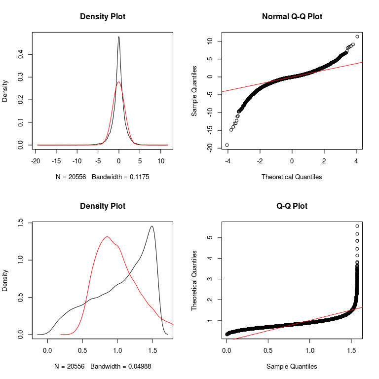

```r
sc_norm <- suppressMessages(normalize_expt(sc, norm="tmm", convert="cpm"))
sp_norm <- suppressMessages(normalize_expt(sp, norm="rle", convert="cpm", transform="log2"))
summary(hs_norm)
```

```
##                        Length Class         Mode
## initial_metadata       38     data.frame    list
## original_expressionset  1     ExpressionSet S4
## expressionset           1     ExpressionSet S4
## design                 38     data.frame    list
## conditions             11     factor        numeric
## batches                11     factor        numeric
## samplenames            11     -none-        character
## colors                 11     -none-        character
## state                   5     -none-        list
## original_libsize       50     -none-        numeric
## libsize                11     -none-        numeric
## backup_expressionset    1     ExpressionSet S4
## normalized              4     -none-        list
## best_libsize           11     -none-        numeric
## norm_result             4     -none-        list
```

```r
## The same fields are here as from before, but with a few new like 'normalized'

summary(hs_norm$normalized)
```

```
##                     Length Class  Mode
## actions                  5 -none- list
## intermediate_counts      7 -none- list
## count_table         226116 -none- numeric
## libsize                 11 -none- numeric
```

```r
## which is a list including the things done, intermediate count tables, and library sizes

hs_norm$normalized$actions
```

```
## $lowfilter
## [1] TRUE
##
## $normalization
## [1] "quant"
##
## $conversion
## [1] "cpm"
##
## $batch
## [1] "combat"
##
## $transform
## [1] "log2"
```

```r
## Here we see that we did log2(combat(cpm(quantile(low-filter(counts)))))

summary(hs_norm$normalized$intermediate_counts)
```

```
##               Length Class      Mode
## original          11 data.frame list
## input         561451 -none-     numeric
## lowfilter          2 -none-     list
## normalization      3 -none-     list
## conversion         2 -none-     list
## batch              2 -none-     list
## transform          2 -none-     list
```

```r
## Each of these slots contains the eset of each step.
```

The return of normalize_expt is another expt object with a few fields filled in. This includes ‘normalized’ which is a list including ‘actions’ which is a list of all the modifications performed on the data. ‘intermediate_counts’ is a list of the changed count table after each step of the normalization process. The order of operations is preserved in the order in which they are printed, thus: input->lowfilter->normalization->conversion->batch->transform.

## Poke at normalized data

Now that these data sets have been normalized, a larger set of plots make sense. For example, if we did a log2 transformation, then the assumptions of a pca plot are no longer so thoroughly violated, and the plot should make a lot more sense.

### Human normalized plots

In the following block I will call separate plotting functions, it is worth noting that they are generally smart enough to tell the difference between an expt object, an expressionset, or just a df count table (perhaps with a design and/or colors).

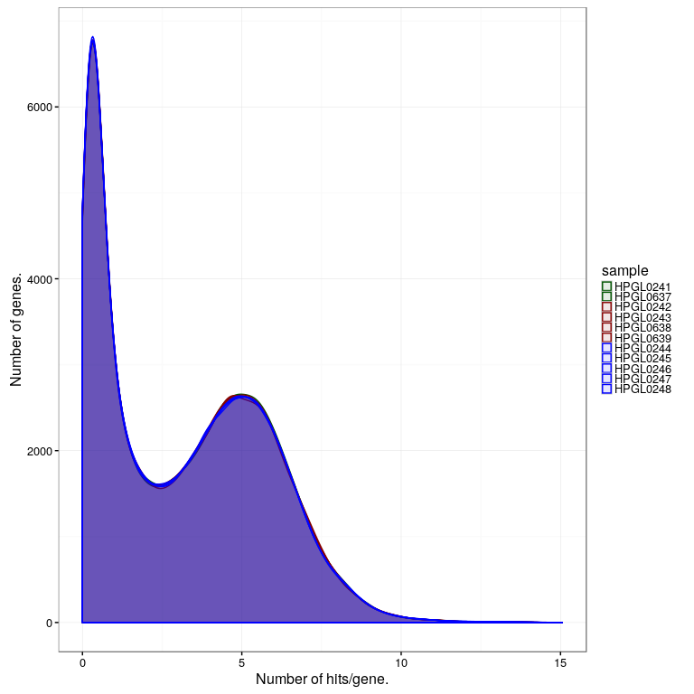

```r
hs_density <- hpgl_density(hs_norm)
print(hs_density)
```

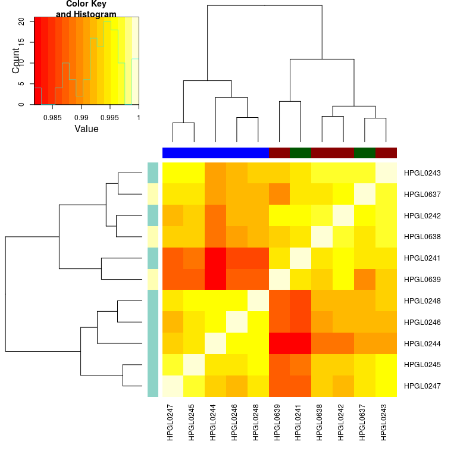

```r
## The quantile normalization really homogenizes the data distributions

hs_cor <- hpgl_corheat(hs_norm)
```

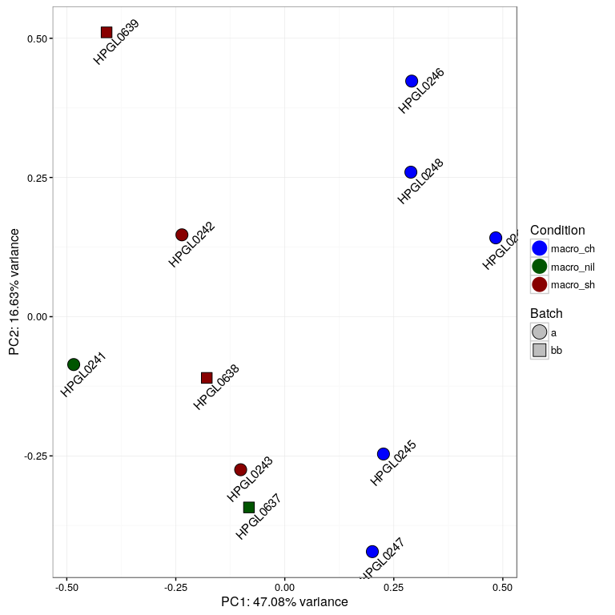

```r
## It appears the uninfected looks a lot like self-healing

hs_pca <- hpgl_pca(hs_norm)
hs_pca$plot
```

```r
## The pca plot now separates pretty clearly from self-healing/uninfected vs. chronic

hs_pca$res
```

```
##    propVar cumPropVar cond.R2 batch.R2
## 1    47.08      47.08   81.88    20.57
## 2    16.63      63.71   11.53     0.15
## 3     9.90      73.61   53.81     1.12
## 4     6.58      80.19    9.74     0.78
## 5     5.35      85.54    0.21     1.28
## 6     4.87      90.41    9.85     0.78
## 7     3.35      93.76    5.29     0.01
## 8     2.85      96.61   21.04     2.21
## 9     2.36      98.97    1.57     0.26
## 10    1.02      99.99    5.09    72.84
```

### Yeast normalized plots

In contrast, since the normalized expt is just another expt, we may call graph_metrics() on it. I am going to suppress the message from it, too.

```r
sc_plots <- suppressMessages(graph_metrics(sc_norm))
```

```
## [1] "There is just one batch in this data."
```

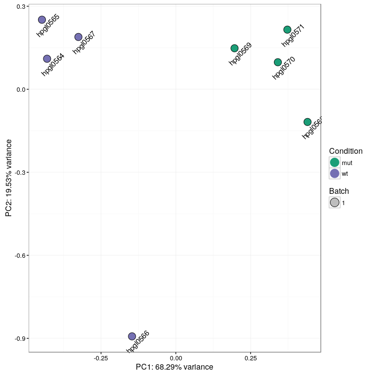

```r
print(sc_plots$pcaplot)
```

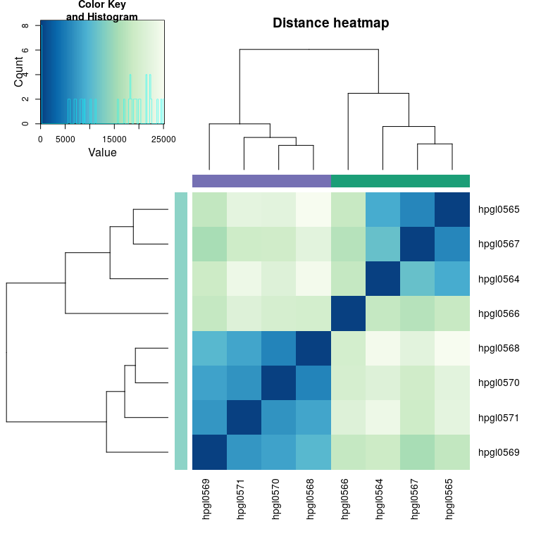

```r
## hpgl0566 is a bit weird

print(sc_plots$disheat)
```

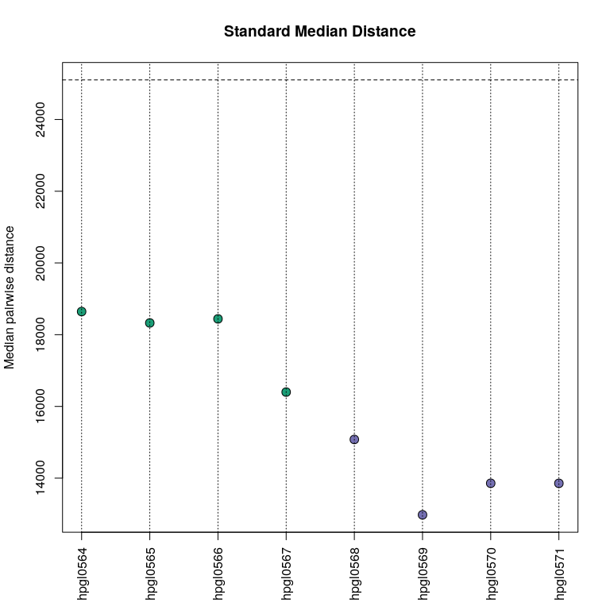

```r
## but the clustering is pretty good

print(sc_plots$smd)
```

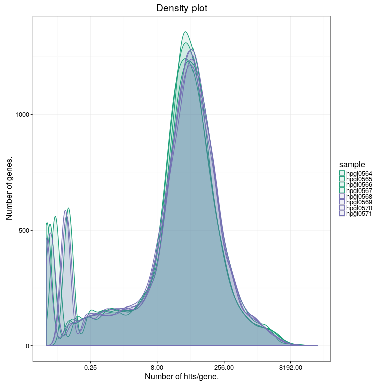

```r
## and even that weird sample is well below the standard median distance cutoff

print(sc_plots$density)
```

### Streptococcus pyogenes normalized plots

Even normalization is insufficient to salvage this data, as we can see below.

```r
sp_plots <- suppressMessages(graph_metrics(sp_norm, qq=TRUE, ma=TRUE))
```

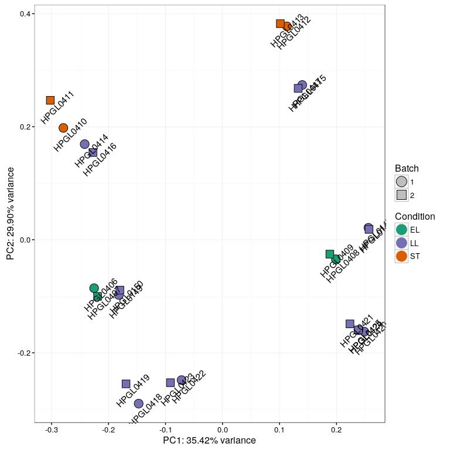

```r
print(sp_plots$pcaplot)
```

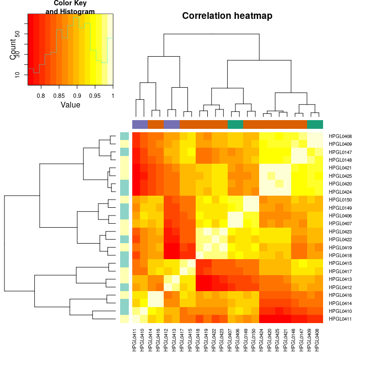

```r
## Some weird clustering is going on, we can see that there is another
## experimental factor which is much more important than our delineation
## between early/late/stationary.

print(sp_plots$corheat)
```

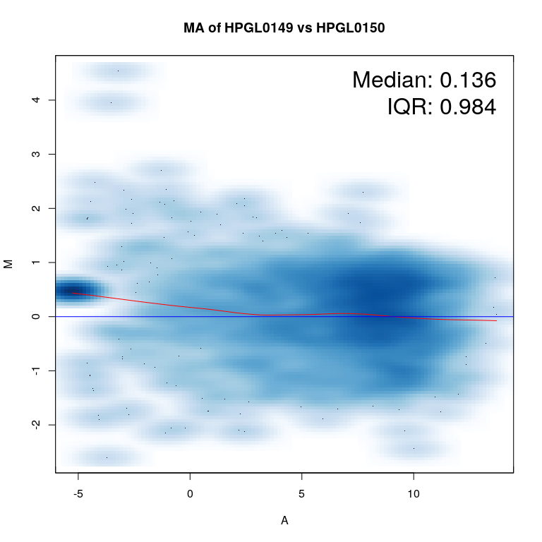

```r
## hmm ok

print(sp_plots$ma$HPGL0149_HPGL0150)
```

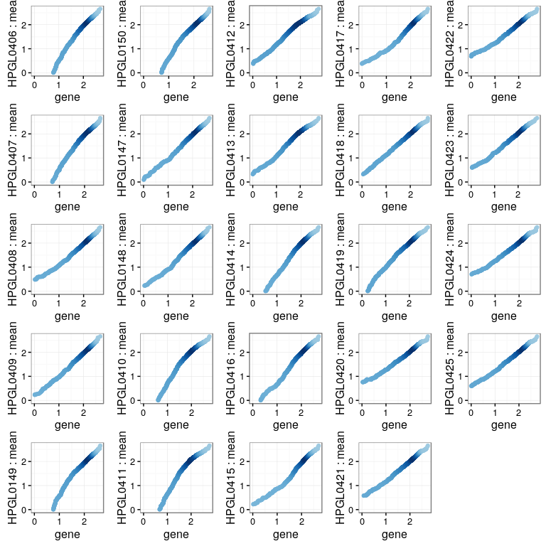

```r
## The ma between these samples is a bit weird

print(sp_plots$qqlog)
```

```r
## clearly some samples are not on the same distribution
## and this is after normalization
```

# Perform a differential expression analysis

Assuming we are satisfied with the data (In the case of the S.pyogenes data, we explicitly are *not*, and the experiment had to be redone.), we can perform various differential expression analyses. Some people prefer limma or edger or deseq, I do not. But if you do, it is possible to perform these analyses separately

## Single DE tools

The following blocks will illustrate how to run limma, edgeR, and DESeq2 separately. In each case, the wrapper will attempt to extract all possible pairwise comparisons of conditions in the data, and run them.

For these, I will use the yeast data set, which if you will recall, has only 1 batch. This is interesting because my tools default to including batch in their models. Thus, if you watch the output, you will see its moment of puzzlement.

### limma

Limma is what we use primarily in our lab, and so I have more options for it than the other tools.

```r
sc_limma <- limma_pairwise(sc_norm)
```

```
## Starting limma pairwise comparison.
```

```
## libsize was not specified, this parameter has profound effects on limma's result.
```

```
## Using the libsize from expt$best_libsize.
```

```
## The condition+batch model failed.  Does your experimental design support both condition and batch?
```

```
## Using only a conditional model.
```

```
## Limma step 1/6: choosing model.
```

```
## Limma step 2/6: running voom
```

```
## The voom input was not log2, transforming now.
```

```
## limma step 3/6: running lmFit
```

```
## Limma step 4/6: making and fitting contrasts.
```

```
## As a reference, the identity is: mut = mut,
```

```
## As a reference, the identity is: wt = wt,
```

```
## Limma step 5/6: Running eBayes and topTable.
```

```
## Limma step 6/6: Writing limma outputs.
```

```
## limma step 6/6: 1/3: Printing table: mut.
```

```
## limma step 6/6: 2/3: Printing table: wt.
```

```
## limma step 6/6: 3/3: Printing table: wt_vs_mut.
```

```r
sc_scatter <- limma_coefficient_scatter(sc_limma)
```

```
## This can do comparisons among the following columns in the limma result:
```

```
## mutwtwt_vs_mut
```

```
## Actually comparing mut and wt.
```

```
## Setting binwidth to 0.0392910953274676 in order to have 500 bins.
```

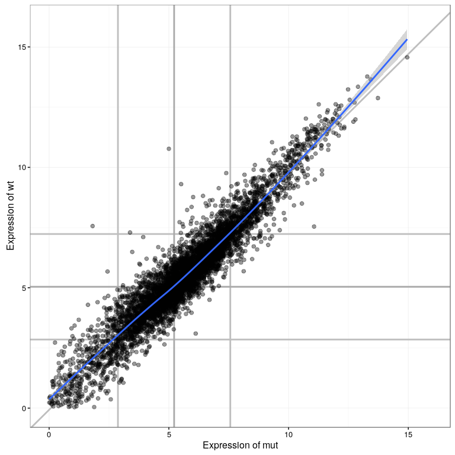

```r
sc_scatter$scatter
```

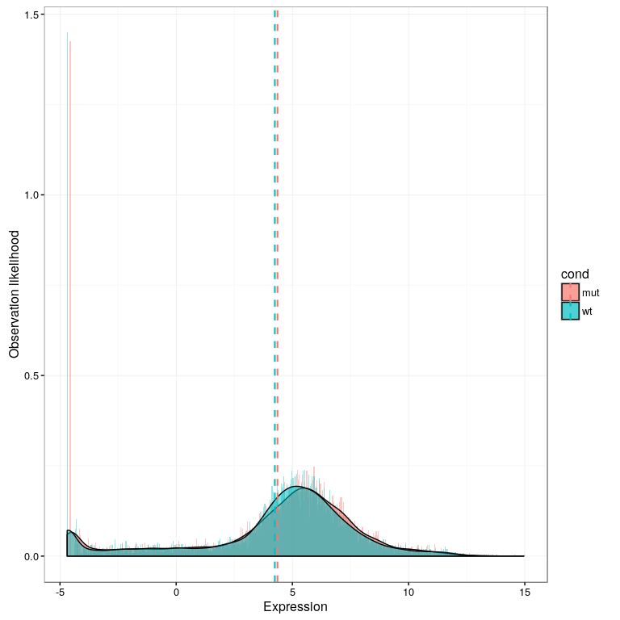

```
##
## $data_summary
##       mut              wt
##  Min.   :-4.56   Min.   :-4.69
##  1st Qu.: 3.30   1st Qu.: 3.34
##  Median : 5.22   Median : 5.04
##  Mean   : 4.36   Mean   : 4.25
##  3rd Qu.: 6.62   3rd Qu.: 6.40
##  Max.   :14.96   Max.   :14.57
##
## $uncor_t
##
##  Pairwise comparisons using t tests with pooled SD
##
## data:  play_all$expression and play_all$cond
##
##    mut
## wt 0.07
##
## P value adjustment method: none
##
## $bon_t
##
##  Pairwise comparisons using t tests with pooled SD
##
## data:  play_all$expression and play_all$cond
##
##    mut
## wt 0.07
##
## P value adjustment method: bonferroni
```

```r
sc_scatter$both_histogram
```

### EdgeR

In contrast, edgeR does not like inputs which have been messed with. It requires a happy negative binomial distribution to work, which assuredly is no longer true when we log2 normalize, for instance. Therefore, you can see its moment of puzzlement and decision to use the raw data.

Oh yeah, I used to color all of my dots by distance from the linear model. This has not changed for this plot.

```r
sc_edger <- edger_pairwise(sc_norm)
```

```
## Starting edgeR pairwise comparisons.
```

```
## EdgeR expects raw data as input, reverting to the original expressionset.
```

```
## EdgeR step 1/9: normalizing data.
```

```
## EdgeR step 2/9: Estimating the common dispersion.
```

```
## EdgeR step 3/9: Estimating dispersion across genes.
```

```
## EdgeR step 4/9: Estimating GLM Common dispersion.
```

```
## EdgeR step 5/9: Estimating GLM Trended dispersion.
```

```
## EdgeR step 6/9: Estimating GLM Tagged dispersion.
```

```
## EdgeR step 7/9: Running glmFit.
```

```
## EdgeR step 8/9: Making pairwise contrasts.
```

```
## As a reference, the identity is: mut = mut,
```

```
## As a reference, the identity is: wt = wt,
```

```
## EdgeR step 9/9: 1/1: Printing table: wt_vs_mut.
```

```r
sc_scatter <- edger_coefficient_scatter(sc_edger)
```

```
## This can do comparisons among the following columns in the edger result:
```

```
## mut wt
```

```
## Actually comparing mut and wt.
```

```
## Setting binwidth to 0.0300734811233812 in order to have 500 bins.
```

```
## [1] 19.47
```

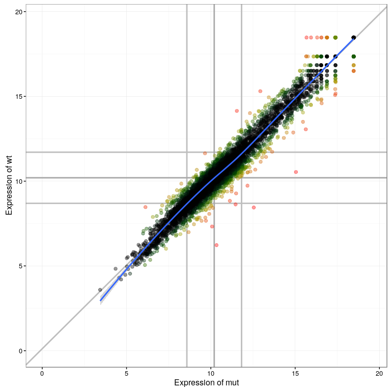

```r
sc_scatter$scatter
```

### DESeq2

```r
sc_deseq <- deseq_pairwise(sc_norm)
```

```
## Hey you, use deseq2 pairwise.
```

```
## Starting DESeq2 pairwise comparisons.
```

```
## DESeq2 demands raw data as input, reverting to the original expressionset.
```

```
## DESeq2 step 1/5: Including only condition in the deseq model.
```

```
## DESeq2 step 2/5: Estimate size factors.
```

```
## DESeq2 step 3/5: estimate Dispersions.
```

```
## DESeq2 step 4/5: nbinomWaldTest.
```

```
## DESeq2 step 5/5: 1/1: Printing table: wt_vs_mut
```

```
## Collected coefficients for: mut
```

```
## Collected coefficients for: wt
```

```r
sc_scatter <- deseq_coefficient_scatter(sc_deseq)
```

```
## This can do comparisons among the following columns in the deseq2 result:
```

```
## mutwt
```

```
## Actually comparing mut and wt.
```

```
## Setting binwidth to 0.044912165934791 in order to have 500 bins.
```

```r
## oops, I broke deseq_coefficient_scatter() FIXME!!
```

### All 3 and a basic non-statistical implementation

I wrote a wrapper for the above 3 tools which does the following:

1. Check if it should include condition or condition+batch in the model
2. Extract all possible conditions
- A subset of conditions may be provided
- Generate a list of all possible pairwise comparisons of the conditions
3. Using limma, perform all comparisons
4. Using DESeq2, perform all comparisons
5. Using EdgeR, perform all comparisons
6. Using the basic method, perform all comparisons
7. Perform correlations among the resulting log fold changes

#### Human all-pairwise

```r
hs_de <- all_pairwise(hs_norm)
```

```
## Starting limma pairwise comparison.
```

```
## libsize was not specified, this parameter has profound effects on limma's result.
```

```
## Using the libsize from expt$best_libsize.
```

```
## Limma step 1/6: choosing model.
```

```
## Limma step 2/6: running voom
```

```
## limma step 3/6: running lmFit
```

```
## Limma step 4/6: making and fitting contrasts.
```

```
## As a reference, the identity is: macro_ch = macro_ch,
```

```
## As a reference, the identity is: macro_nil = macro_nil,
```

```
## As a reference, the identity is: macro_sh = macro_sh,
```

```
## Limma step 5/6: Running eBayes and topTable.
```

```
## Limma step 6/6: Writing limma outputs.
```

```
## limma step 6/6: 1/6: Printing table: macro_ch.
```

```
## limma step 6/6: 2/6: Printing table: macro_nil.
```

```
## The qvalue estimation failed for macro_nil.
```

```
## limma step 6/6: 3/6: Printing table: macro_sh.
```

```
## The qvalue estimation failed for macro_sh.
```

```
## limma step 6/6: 4/6: Printing table: macro_nil_vs_macro_ch.
```

```
## limma step 6/6: 5/6: Printing table: macro_sh_vs_macro_ch.
```

```
## limma step 6/6: 6/6: Printing table: macro_sh_vs_macro_nil.
```

```
## Starting DESeq2 pairwise comparisons.
```

```
## DESeq2 demands raw data as input, reverting to the original expressionset.
```

```
## DESeq2 step 1/5: Including batch and condition in the deseq model.
```

```
## DESeq2 step 2/5: Estimate size factors.
```

```
## DESeq2 step 3/5: estimate Dispersions.
```

```
## DESeq2 step 4/5: nbinomWaldTest.
```

```
## DESeq2 step 5/5: 1/3: Printing table: macro_nil_vs_macro_ch
```

```
## DESeq2 step 5/5: 2/3: Printing table: macro_sh_vs_macro_ch
```

```
## DESeq2 step 5/5: 3/3: Printing table: macro_sh_vs_macro_nil
```

```
## Collected coefficients for: macro_ch
```

```
## Collected coefficients for: macro_nil
```

```
## Collected coefficients for: macro_sh
```

```
## Starting edgeR pairwise comparisons.
```

```
## EdgeR expects raw data as input, reverting to the original expressionset.
```

```
## EdgeR step 1/9: normalizing data.
```

```
## EdgeR step 2/9: Estimating the common dispersion.
```

```
## EdgeR step 3/9: Estimating dispersion across genes.
```

```
## EdgeR step 4/9: Estimating GLM Common dispersion.
```

```
## EdgeR step 5/9: Estimating GLM Trended dispersion.
```

```
## EdgeR step 6/9: Estimating GLM Tagged dispersion.
```

```
## EdgeR step 7/9: Running glmFit.
```

```
## EdgeR step 8/9: Making pairwise contrasts.
```

```
## As a reference, the identity is: macro_ch = macro_ch,
```

```
## As a reference, the identity is: macro_nil = macro_nil,
```

```
## As a reference, the identity is: macro_sh = macro_sh,
```

```
## EdgeR step 9/9: 1/3: Printing table: macro_nil_vs_macro_ch.
```

```
## EdgeR step 9/9: 2/3: Printing table: macro_sh_vs_macro_ch.
```

```
## EdgeR step 9/9: 3/3: Printing table: macro_sh_vs_macro_nil.
```

```
## Starting basic pairwise comparison.
```

```
## Basic step 1/3: Creating median and variance tables.
```

```
## Basic step 2/3: Performing comparisons.
```

```
## Basic step 2/3: 1/3: Performing log2 subtraction: macro_nil_vs_macro_ch
```

```
## Basic step 2/3: 2/3: Performing log2 subtraction: macro_sh_vs_macro_ch
```

```
## Basic step 2/3: 3/3: Performing log2 subtraction: macro_sh_vs_macro_nil
```

```
## Basic step 3/3: Creating faux DE Tables.
```

```
## Basic: Returning tables.
```

```
## 1/3: Comparing analyses: macro_nil_vs_macro_ch
```

```
## 2/3: Comparing analyses: macro_sh_vs_macro_ch
```

```
## 3/3: Comparing analyses: macro_sh_vs_macro_nil
```

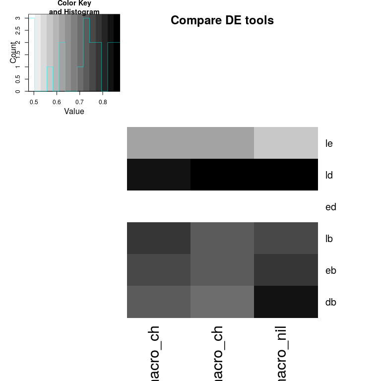

```r
## The data structure presented by doing all these tools is of a necessity
## quite complex.
print(hs_de$comparison$heat)
## This provides a summary of how well the various tools (dis)agree.

## Extracts of the data may be taken:
hs_keepers <- list(
    "chr_vs_sh" = c("macro_ch","macro_sh"))
## This makes a label 'chr_vs_sh', standing for chronic/self-healing
## It uses the macro_ch condition as numerator, and macro_sh as denominator.
hs_combined <- combine_de_tables(hs_de, keepers=hs_keepers, excel=NULL)
```

```
## Working on 1/1: chr_vs_sh
```

```
## The table is: macro_sh_vs_macro_ch
```

```
##                  table total limma_up limma_sigup deseq_up deseq_sigup edger_up
## 2 macro_sh_vs_macro_ch 20556       66          30        3           2      912
##   edger_sigup basic_up basic_sigup limma_down limma_sigdown deseq_down deseq_sigdown
## 2         121       21          17         58            33         52            48
##   edger_down edger_sigdown basic_down basic_sigdown meta_up meta_sigup meta_down
## 2        714           198          1             0      90         81       160
##   meta_sigdown
## 2          157
```

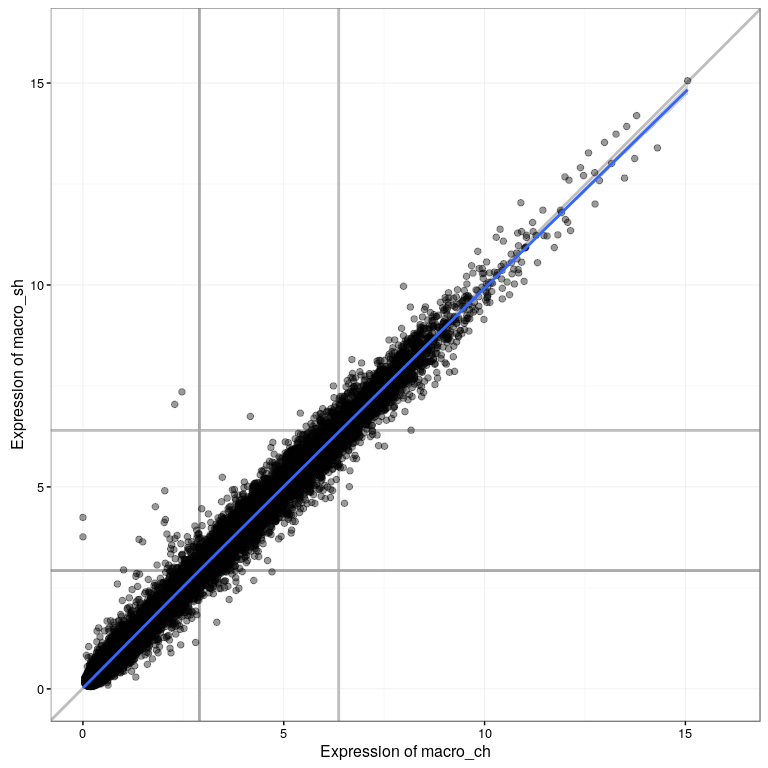

```r
hs_combined$plots
```

```r
## The coefficient scatter plot from limma

hs_sig <- extract_significant_genes(hs_combined, excel=NULL)
```

```
## Writing excel data sheet 1/1
```

```
## Assuming the fold changes are on the log scale and so taking >< 0
```

```
## After (adj)p filter, the up genes table has 701 genes.
```

```
## After (adj)p filter, the down genes table has 486 genes.
```

```
## Assuming the fold changes are on the log scale and so taking -1 * fc
```

```
## After fold change filter, the up genes table has 30 genes.
```

```
## After fold change filter, the down genes table has 33 genes.
```

```
## Not printing excel sheets for the significant genes.
```

```r
## I made some attempt to standardize the columns from the various tools
## when presenting them all together.
knitr::kable(head(hs_sig$limma$ups$chr_vs_sh))
```

|  | limma_logfc | deseq_logfc | edger_logfc | limma_adjp | deseq_adjp | edger_adjp | limma_ave | limma_t | limma_p | limma_b | limma_q | deseq_basemean | deseq_lfcse | deseq_stat | deseq_p | deseq_q | edger_logcpm | edger_lr | edger_p | edger_q | basic_nummed | basic_denmed | basic_numvar | basic_denvar | basic_logfc | basic_t | basic_p | fc_meta | fc_var | … |
| --- | --- | --- | --- | --- | --- | --- | --- | --- | --- | --- | --- | --- | --- | --- | --- | --- | --- | --- | --- | --- | --- | --- | --- | --- | --- | --- | --- | --- | --- | --- |
| ENSG00000137673 | 4.889 | 0.4763 | 1.5010 | 0.0470 | 0.2025 | 0.0531 | 5.175 | 3.841 | 0.0024 | -1.3200 | 0.0300 | 1615.0 | 0.2597 | 1.834 | 0.0666 | 0.7239 | 6.645 | 10.330 | 0.0013 | 5.315e-02 | 122.20 | 7.826 | 7.738e+01 | 2.825e+03 | 3.9650 | -3.087 | 3.360e-02 | 1.732 | 2.561e+00 | … |
| ENSG00000226958 | 4.243 | 0.3955 | 0.8894 | 0.0355 | 0.3161 | 0.6357 | 3.676 | 4.357 | 0.0010 | -0.4968 | 0.0227 | 2598.0 | 0.2642 | 1.497 | 0.1344 | 1.0000 | 7.329 | 3.218 | 0.0728 | 6.356e-01 | 100.40 | 7.823 | 2.248e+03 | 7.683e-06 | 3.6820 | -3.545 | 3.823e-02 | 1.418 | 2.223e+00 | … |
| ENSG00000159674 | 2.869 | 0.4311 | 1.4110 | 0.0355 | 0.2570 | 0.0614 | 3.646 | 4.374 | 0.0009 | -0.4313 | 0.0227 | 307.0 | 0.2592 | 1.663 | 0.0963 | 0.8924 | 4.267 | 9.939 | 0.0016 | 6.136e-02 | 81.99 | 28.150 | 2.589e+01 | 7.148e+02 | 1.5420 | -3.454 | 2.262e-02 | 1.372 | 1.225e+00 | … |
| ENSG00000164120 | 2.097 | 0.9020 | 1.3860 | 0.0275 | 0.0056 | 0.0007 | 3.151 | 5.184 | 0.0002 | 0.8090 | 0.0176 | 167.7 | 0.2465 | 3.660 | 0.0003 | 0.0219 | 3.419 | 22.350 | 0.0000 | 7.177e-04 | 70.34 | 35.620 | 1.433e+01 | 2.254e+02 | 0.9817 | -4.407 | 8.372e-03 | 1.649 | 4.626e-01 | … |
| ENSG00000106992 | 1.768 | 0.6549 | 1.0200 | 0.0362 | 0.0455 | 0.0210 | 4.447 | 4.324 | 0.0010 | -0.5344 | 0.0231 | 403.8 | 0.2424 | 2.702 | 0.0069 | 0.1727 | 4.653 | 13.110 | 0.0003 | 2.104e-02 | 87.19 | 56.830 | 5.774e+00 | 2.406e+02 | 0.6177 | -3.604 | 2.055e-02 | 1.203 | 3.760e-01 | … |
| ENSG00000116299 | 1.502 | 0.8016 | 1.0090 | 0.0252 | 0.0015 | 0.0002 | 3.792 | 5.535 | 0.0001 | 1.3400 | 0.0161 | 238.8 | 0.1931 | 4.151 | 0.0000 | 0.0058 | 3.914 | 26.400 | 0.0000 | 1.647e-04 | 76.17 | 56.270 | 2.447e+01 | 5.336e+01 | 0.4368 | -5.242 | 1.261e-03 | 1.295 | 3.322e-01 | … |

The all_pairwise() function does more than we usually want. When it performs all possible contrasts, that provides a larger landscape to test that the various tools (dis)agree, but it also produces tables which are excessive and may be reversed with respect to our logical way of thinking about the samples. Eg. This tool might provide b/a when in fact we care about a/b. Furthermore, it provides no judgement regarding which genes are ‘significant’.

#### Yeast all pairwise

The yeast data has only 1 batch, we can make that explicit when we call all_pairwise() In addition, the yeast data is relatively well behaved, thus it agrees across the board.

```r
sc_de <- suppressMessages(all_pairwise(sc_norm, model_batch=FALSE))
sc_combined <- combine_de_tables(sc_de)
```

```
## Working on table 1/1: wt_vs_mut
```

```
## The table is: wt_vs_mut
```

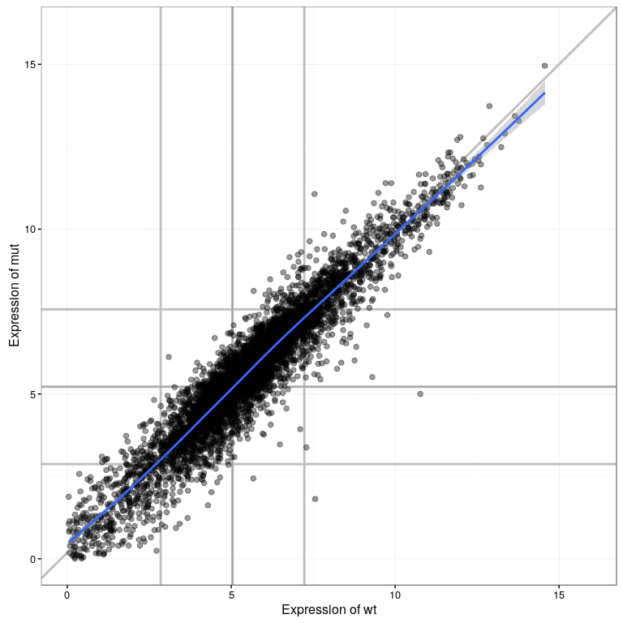

```r
sc_combined$plots
```

```r
## There is a bigger range of data for the yeast, primarily because we didn't have
## to smash it with a comBat

sc_sig <- extract_significant_genes(sc_combined, according_to="edger", fc=0.7, z=1, excel=NULL)
```

```
## Writing excel data sheet 1/1
```

```
## Assuming the fold changes are on the log scale and so taking >< 0
```

```
## After (adj)p filter, the up genes table has 1602 genes.
```

```
## After (adj)p filter, the down genes table has 1458 genes.
```

```
## Assuming the fold changes are on the log scale and so taking -1 * fc
```

```
## After fold change filter, the up genes table has 888 genes.
```

```
## After fold change filter, the down genes table has 632 genes.
```

```
## Getting the genes >= 1 z scores away from the median of all.
```

```
## After z filter, the up genes table has 888 genes.
```

```
## After z filter, the down genes table has 632 genes.
```

```
## Not printing excel sheets for the significant genes.
```

As you can see, it is possible to ask for interesting subsets of the available search space, taking a set of contrasts which might be hundreds long and extracting the handful in which one has interest. Furthermore, the definition of ‘significant’ may be changed to suit the requirements of the experiment. Thus the defaults are a +/- 2 fold change with (adj)p <= 0.05. But one may instead request genes outside of a z-score cutoff, a top-n, a p-value, adj-p, or combination.

#### S. pyogenes all pairwise

```r
sp_de <- suppressMessages(all_pairwise(sp))
```

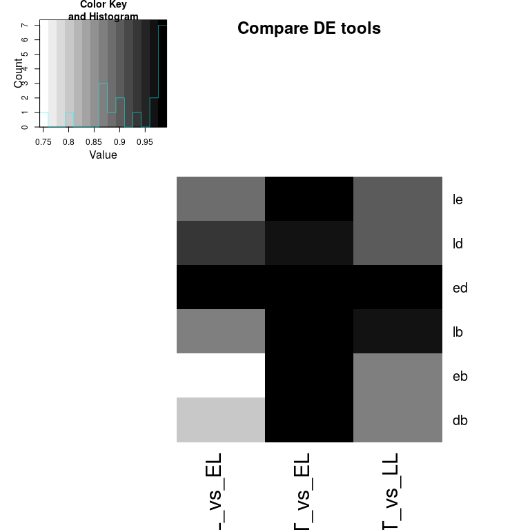

```r
sp_keepers <- list(
    "late-early" = c("LL","EL"),
    "stat-early" = c("ST","EL"))
sp_combined <- combine_de_tables(sp_de, keepers=sp_keepers, excel=NULL)
```

```
## Working on 1/2: late-early
```

```
## The table is: LL_vs_EL
```

```
##      table total limma_up limma_sigup deseq_up deseq_sigup edger_up edger_sigup basic_up
## 2 LL_vs_EL  1950      124          29      293         119      314         116       84
##   basic_sigup limma_down limma_sigdown deseq_down deseq_sigdown edger_down edger_sigdown
## 2          76        336           212        136            92        159            75
##   basic_down basic_sigdown meta_up meta_sigup meta_down meta_sigdown
## 2        484           226     239         86       202          146
```

```
## Working on 2/2: stat-early
```

```
## The table is: ST_vs_EL
```

```
##       table total limma_up limma_sigup deseq_up deseq_sigup edger_up edger_sigup basic_up
## 2  LL_vs_EL  1950      124          29      293         119      314         116       84
## 21 ST_vs_EL  1950      271         165      510         302      529         298      286
##    basic_sigup limma_down limma_sigdown deseq_down deseq_sigdown edger_down edger_sigdown
## 2           76        336           212        136            92        159            75
## 21         206        901           757        401           353        453           301
##    basic_down basic_sigdown meta_up meta_sigup meta_down meta_sigdown
## 2         484           226     239         86       202          146
## 21        908           810     411        171       584          452
```

```r
sp_sig <- extract_significant_genes(sp_combined, according_to="all", excel=NULL)
```

```
## Writing excel data sheet 1/2
```

```
## Assuming the fold changes are on the log scale and so taking >< 0
```

```
## After (adj)p filter, the up genes table has 47 genes.
```

```
## After (adj)p filter, the down genes table has 298 genes.
```

```
## Assuming the fold changes are on the log scale and so taking -1 * fc
```

```
## After fold change filter, the up genes table has 29 genes.
```

```
## After fold change filter, the down genes table has 212 genes.
```

```
## Writing excel data sheet 2/2
```

```
## Assuming the fold changes are on the log scale and so taking >< 0
```

```
## After (adj)p filter, the up genes table has 184 genes.
```

```
## After (adj)p filter, the down genes table has 805 genes.
```

```
## Assuming the fold changes are on the log scale and so taking -1 * fc
```

```
## After fold change filter, the up genes table has 165 genes.
```

```
## After fold change filter, the down genes table has 757 genes.
```

```
## Not printing excel sheets for the significant genes.
```

```
## Writing excel data sheet 3/2
```

```
## Assuming the fold changes are on the log scale and so taking >< 0
```

```
## After (adj)p filter, the up genes table has 118 genes.
```

```
## After (adj)p filter, the down genes table has 81 genes.
```

```
## Assuming the fold changes are on the log scale and so taking -1 * fc
```

```
## After fold change filter, the up genes table has 116 genes.
```

```
## After fold change filter, the down genes table has 75 genes.
```

```
## Writing excel data sheet 4/2
```

```
## Assuming the fold changes are on the log scale and so taking >< 0
```

```
## After (adj)p filter, the up genes table has 298 genes.
```

```
## After (adj)p filter, the down genes table has 301 genes.
```

```
## Assuming the fold changes are on the log scale and so taking -1 * fc
```

```
## After fold change filter, the up genes table has 298 genes.
```

```
## After fold change filter, the down genes table has 301 genes.
```

```
## Not printing excel sheets for the significant genes.
```

```
## Writing excel data sheet 5/2
```

```
## Assuming the fold changes are on the log scale and so taking >< 0
```

```
## After (adj)p filter, the up genes table has 210 genes.
```

```
## After (adj)p filter, the down genes table has 171 genes.
```

```
## Assuming the fold changes are on the log scale and so taking -1 * fc
```

```
## After fold change filter, the up genes table has 119 genes.
```

```
## After fold change filter, the down genes table has 92 genes.
```

```
## Writing excel data sheet 6/2
```

```
## Assuming the fold changes are on the log scale and so taking >< 0
```

```
## After (adj)p filter, the up genes table has 360 genes.
```

```
## After (adj)p filter, the down genes table has 432 genes.
```

```
## Assuming the fold changes are on the log scale and so taking -1 * fc
```

```
## After fold change filter, the up genes table has 302 genes.
```

```
## After fold change filter, the down genes table has 353 genes.
```

```
## Not printing excel sheets for the significant genes.
```

```r
knitr::kable(sp_sig$limma$counts)
```

|  | change_counts_up | change_counts_down |
| --- | --- | --- |
| late-early | 29 | 212 |
| stat-early | 165 | 757 |

```r
knitr::kable(sp_sig$edger$counts)
```

|  | change_counts_up | change_counts_down |
| --- | --- | --- |
| late-early | 116 | 75 |
| stat-early | 298 | 301 |

```r
knitr::kable(sp_sig$deseq$counts)
```

|  | change_counts_up | change_counts_down |
| --- | --- | --- |
| late-early | 119 | 92 |
| stat-early | 302 | 353 |

We know a priori that the S.pyogenes data is screwed up, but we can still pass it along to these tools. We see that the various tools agree pretty well, but we probably cannot trust any of these results.

# Gene Ontology Searching

We have beaten the differential expression horse pretty much to death. Now let us look at some potential ontology searches.

I take the same approach to ontology searches as I do toward differential expression analyses. There are currently 4 main tools used for these searches in the lab:

## Single ontology searches

In the same way all_pairwise() wraps the various differential expression tools, so too do subset_ontology_search() and all_ontology_searches(). But, we may also run the various tools alone.

### goseq

The function simple_goseq() seeks to make a goseq search less onerous. However, it explicitly requires a table of differentially expressed genes.

```r
sc_up <- sc_sig$edger$ups$wt_vs_mut
## sc_genelengths came from waaaaay at the top of this document
sc_goseq <- simple_goseq(sc_up, lengths=sc_genelengths, goids=sc_goids)
```

```
## simple_goseq() makes some pretty hard assumptions about the data it is fed:
```

```
## It requires 2 tables, one of GOids which must have columns (gene)ID and GO(category)
```

```
## The other table is of gene lengths with columns (gene)ID and (gene)width.
```

```
## Other columns are fine, but ignored.
```

```
## simple_goseq(): Using the explicit lengths df for gene lengths.
```

```
## simple_goseq(): Using the length data to fill in the de vector.
```

```
## Using manually entered categories.
```

```
## Calculating the p-values...
```

```
## simple_goseq(): Calculating q-values
```

```
## simple_goseq(): Filling godata with terms, this is slow.
```

```
## Testing that go categories are defined.
```

```
## Removing undefined categories.
```

```
## Gathering synonyms.
```

```
## Gathering category definitions.
```

```
## simple_goseq(): Making pvalue plots for the ontologies.
```

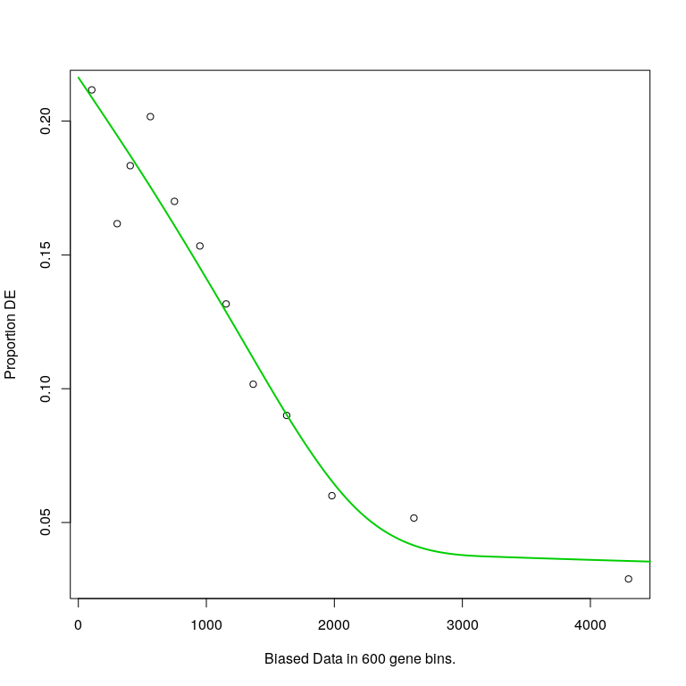

```r
knitr::kable(head(sc_goseq$bp_subset))
```

|  | category | over_represented_pvalue | under_represented_pvalue | numDEInCat | numInCat | term | ontology | qvalue |
| --- | --- | --- | --- | --- | --- | --- | --- | --- |
| 2035 | GO:0008652 | 0e+00 | 1.0000 | 37 | 98 | cellular amino acid biosynthetic process | BP | 0.0000 |
| 1601 | GO:0006526 | 0e+00 | 1.0000 | 8 | 9 | arginine biosynthetic process | BP | 0.0002 |
| 2100 | GO:0009086 | 0e+00 | 1.0000 | 13 | 31 | methionine biosynthetic process | BP | 0.0058 |
| 3332 | GO:0033235 | 3e-04 | 1.0000 | 4 | 5 | positive regulation of protein sumoylation | BP | 0.1205 |
| 1769 | GO:0006888 | 4e-04 | 0.9999 | 22 | 79 | ER to Golgi vesicle-mediated transport | BP | 0.1540 |
| 506 | GO:0002181 | 5e-04 | 0.9998 | 44 | 155 | cytoplasmic translation | BP | 0.1810 |

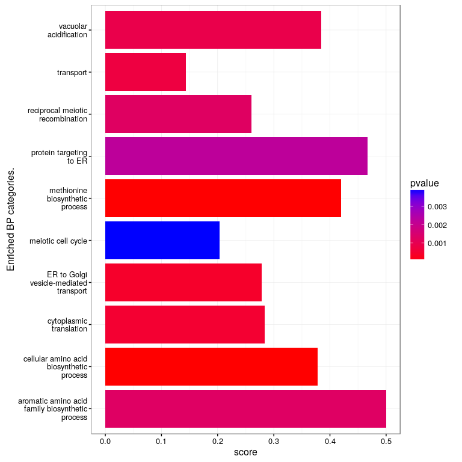

```r
print(sc_goseq$pvalue_plots$bpp_plot_over)
```

### clusterProfiler

ClusterProfiler is rather more conservative than the other tools. Also, it takes a long time for it to generate the rdata files it needs to run, since I already generated them in my yeast working directory, I will just take advantage of the previously existing files.

```r
setwd("~/scratch/rnaseq_cbf5")
sc_clust <- simple_clusterprofiler(sc_up, goids=sc_goids)
```

```
## simple_clus(): Starting MF(molecular function) analysis
```

```
## The minimum observed pvalue is: 0.000720
## The minimum observed pvalue is: 0.000720
```

```
## simple_clus(): Starting BP(biological process) analysis
```

```
## The minimum observed pvalue is: 0.000003
## The minimum observed pvalue is: 0.000003
```

```
## simple_clus(): Starting CC(cellular component) analysis
```

```
## The minimum observed pvalue is: 0.000001
## The minimum observed pvalue is: 0.000001
```

```r
summary(sc_clust)
```

```
##                 Length Class         Mode
## de_genes        32     data.frame    list
## mf_interesting  10     data.frame    list
## bp_interesting  10     data.frame    list
## cc_interesting  10     data.frame    list
## mf_pvals         9     gg            list
## bp_pvals         9     gg            list
## cc_pvals         9     gg            list
## mf_enriched      1     enrichResult  S4
## bp_enriched      1     enrichResult  S4
## cc_enriched      1     enrichResult  S4
## mf_all           1     enrichResult  S4
## bp_all           1     enrichResult  S4
## cc_all           1     enrichResult  S4
## mf_cnetplot      0     -none-        NULL
## bp_cnetplot      0     -none-        NULL
## cc_cnetplot      0     -none-        NULL
## mf_group         1     groupGOResult S4
## bp_group         1     groupGOResult S4
## cc_group         1     groupGOResult S4
## pvalue_allplots  3     -none-        list
## pvalue_plots     3     -none-        list
## cnetplots        3     -none-        list
## group_plots      3     -none-        list
```

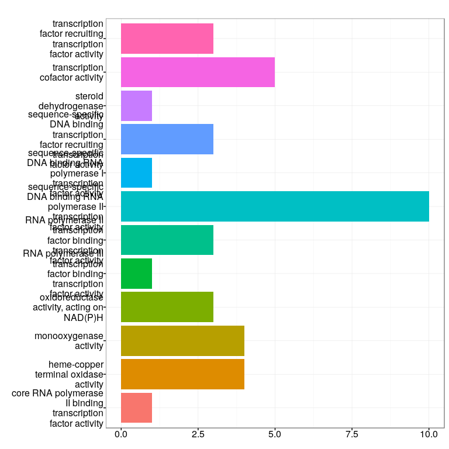

```r
print(sc_clust$group_plots$mf_group_barplot)
```

```r
knitr::kable(head(sc_clust$bp_interesting))
```

| ID | ont | GeneRatio | BgRatio | pvalue | p.adjust | qvalue | geneID | Count | Description |
| --- | --- | --- | --- | --- | --- | --- | --- | --- | --- |
| GO:0008652 | BP | 41/888 | 144/6379 | 0 | 0 | 0.0012 | HIS3/ARG7/MET17/ARG3/MET14/HIS4/ARG4/ARG1/HOM3/HIS1/CPA2/STR…… | 41 | cellular amino acid biosynthetic process |
| GO:0016053 | BP | 51/888 | 195/6379 | 0 | 0 | 0.0012 | HIS3/ARG7/MET17/ARG3/PPT2/MET14/HIS4/BNA1/ARG4/PHS1/ARG1/HOM…… | 51 | organic acid biosynthetic process |
| GO:0046394 | BP | 51/888 | 195/6379 | 0 | 0 | 0.0012 | HIS3/ARG7/MET17/ARG3/PPT2/MET14/HIS4/BNA1/ARG4/PHS1/ARG1/HOM…… | 51 | carboxylic acid biosynthetic process |
| GO:0044283 | BP | 73/888 | 320/6379 | 0 | 0 | 0.0019 | HIS3/ARG7/MET17/ARG3/PPT2/RIB4/MET14/HIS4/BNA1/ARG4/PHS1/EPT…… | 73 | small molecule biosynthetic process |
| GO:0002181 | BP | 45/888 | 171/6379 | 0 | 0 | 0.0021 | RPS22B/RPL22B/RPS17B/RPS10B/RPS9A/RPL30/RPL38/RPL40A/RPL12B/…… | 45 | cytoplasmic translation |
| GO:1901607 | BP | 38/888 | 136/6379 | 0 | 0 | 0.0021 | HIS3/ARG7/MET17/ARG3/MET14/HIS4/ARG4/ARG1/HOM3/HIS1/CPA2/STR3/MET16/SER3/ORT1/MET22/LYS5/HIS5/ARG2/ARG8/SAM4/MET6/HOM2/MET10/MET3/HOM6/ADI1/LYS21/TRP4/SER33/ARO7/CIT2/IDP1/TRP2/LYS1/LYS2/LEU9/ILV6 | 38 | alpha-amino acid biosynthetic process |

### topGO

topGO talks too much. suppressMessages doesn’t seem to shut it up, either. As a result, I am going to set a flag on this block to tell it to ignore the voluminous output from topgo.

```r
setwd("~/scratch/rnaseq_cbf5")
sc_top <- simple_topgo(sc_up)
```

```
## simple_topgo(): Set densities=TRUE for ontology densitya plots.
```

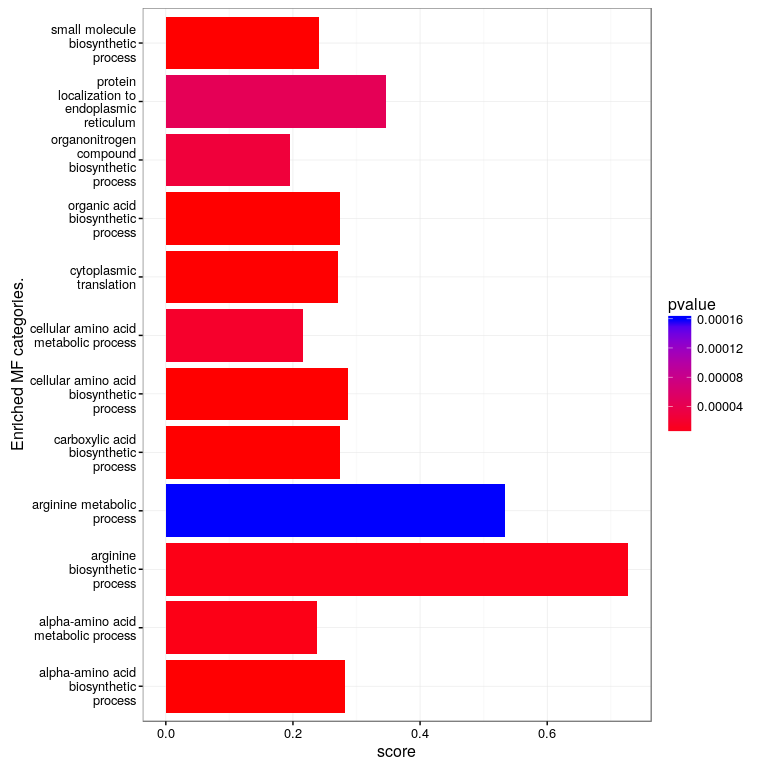

```r
sc_top$pvalue_plots$bpp_plot_over
```

```r
knitr::kable(head(sc_top$tables$bp_interesting))
```

| GO.ID | ont | Annotated | Significant | Expected | fisher | qvalue | KS | EL | weight | Term |
| --- | --- | --- | --- | --- | --- | --- | --- | --- | --- | --- |
| GO:0044283 | BP | 315 | 76 | 39.06 | 0 | 0e+00 | 1.4e-25 | 0.07756 | 0.91951 | small molecule biosynthetic process |
| GO:0016053 | BP | 190 | 52 | 23.56 | 0 | 0e+00 | 2.3e-25 | 0.01966 | 0.91056 | organic acid biosynthetic process |
| GO:0046394 | BP | 190 | 52 | 23.56 | 0 | 0e+00 | 2.3e-25 | 0.01966 | 0.91667 | carboxylic acid biosynthetic process |
| GO:0008652 | BP | 143 | 41 | 17.73 | 0 | 1e-04 | 3.4e-19 | 0.00835 | 0.94018 | cellular amino acid biosynthetic process |
| GO:0002181 | BP | 166 | 45 | 20.59 | 0 | 2e-04 | 1.1e-13 | 0.00054 | 2.5e-07 | cytoplasmic translation |
| GO:1901607 | BP | 135 | 38 | 16.74 | 0 | 4e-04 | 3.9e-17 | 0.04021 | 0.89147 | alpha-amino acid biosynthetic process |

### GOstats

GOstats is neat because it is good about using the suite of existing bioconductor tools.

```r
setwd("~/scratch/rnaseq_cbf5")
sc_gost <- simple_gostats(sc_up, gff="reference/scerevisiae.gff.gz", goids=sc_goids, gff_type="gene")
```

```
## The namespaces/environments uses by GOstats are entirely too complex.
```

```
## If I try to call functions with Category:: or GOstats:: then they collide
```

```
## And things fail without error, but if I try library() then R CMD check
```

```
## gets pissed, well I tried both ways and I am calling library().
```

```
## R CMD check can bit my shiny metal ass.
```

```
## simple_gostats(): gff_type is: gene. Change that if there are bad merges.
```

```
## simple_gostats(): type CDS has 0 annotations.
```

```
## simple_gostats(): type gene has 7050 annotations.
```

```
## simple_gostats(): type exon has 0 annotations.
```

```
## simple_gostats(): the current annotations has: 7050 rows and 18 columns.
```

```
## simple_gostats(): Creating the gene set collection.  This is slow.
```

```
## simple_gostats(): Performing MF GSEA.
```

```
## Found 66 over MF categories.
```

```
## simple_gostats(): Performing BP GSEA.
```

```
## Found 214 over BP categories.
```

```
## simple_gostats(): Performing CC GSEA.
```

```
## Found 97 over CC categories.
```

```
## simple_gostats(): Performing under MF GSEA.
```

```
## Found 118 under MF categories.
```

```
## simple_gostats(): Performing under BP GSEA.
```

```
## Found 448 under BP categories.
```

```
## simple_gostats(): Performing under CC GSEA.
```

```
## Found 56 under CC categories.
```

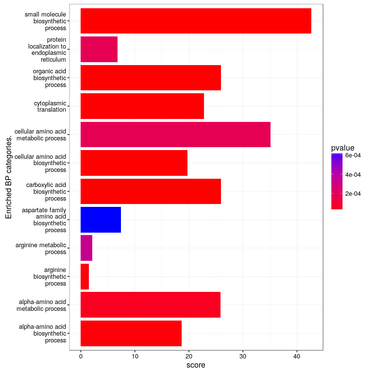

```r
sc_gost$pvalue_plots$bpp_plot_over
```

### gProfiler

gprofiler hasnot yet been incorporated into the all_ontology tools.

```r
sc_gprof <- simple_gprofiler(sc_up, organism="scerevisiae")
```

```
## Performing g:Profiler GO search.
```

```
## Performing g:Profiler KEGG search.
```

```
## Performing g:Profiler reactome.db search.
```

```
## Performing g:Profiler mi search.
```

```
## Performing g:Profiler tf search.
```

```
## Performing g:Profiler corum search.
```

```
## Performing g:Profiler hp search.
```

```r
knitr::kable(head(sc_gprof$kegg))
```

| query.number | significant | p.value | term.size | query.size | overlap.size | recall | precision | term.id | domain | subgraph.number | term.name | relative.depth | intersection |
| --- | --- | --- | --- | --- | --- | --- | --- | --- | --- | --- | --- | --- | --- |
| 1 | TRUE | 0.0486 | 8 | 461 | 4 | 0.009 | 0.500 | KEGG:00062 | ke | 10 | Fatty acid elongation | 1 | TSC13,PHS1,ELO1,SUR4 |
| 1 | TRUE | 0.0246 | 14 | 79 | 3 | 0.038 | 0.214 | KEGG:00340 | ke | 7 | Histidine metabolism | 1 | HIS4,HIS1,HIS3 |
| 1 | TRUE | 0.0020 | 15 | 351 | 6 | 0.017 | 0.400 | KEGG:00920 | ke | 9 | Sulfur metabolism | 1 | MET10,MET3,MET14,MET17,MET22,MET16 |
| 1 | TRUE | 0.0216 | 40 | 264 | 7 | 0.027 | 0.175 | KEGG:00270 | ke | 3 | Cysteine and methionine metabolism | 1 | HOM2,SAM2,HOM3,MET6,STR3,MET17,SAM4 |
| 1 | TRUE | 0.0090 | 22 | 411 | 7 | 0.017 | 0.318 | KEGG:03060 | ke | 1 | Protein export | 1 | SRP14,SSS1,SPC1,SPC3,SPC2,IMP2,SRP68 |
| 1 | TRUE | 0.0000 | 123 | 272 | 18 | 0.066 | 0.146 | KEGG:01230 | ke | 4 | Biosynthesis of amino acids | 1 | HIS4,ARO3,HOM2,SAM2,HOM3,HIS1,SER3,MET6,STR3,ARG4,HIS5,ARG2,ARG3,MET17,ARG7,ARG1,ARG8,HIS3 |

```r
knitr::kable(head(sc_gprof$reactome))
```

| query.number | significant | p.value | term.size | query.size | overlap.size | recall | precision | term.id | domain | subgraph.number | term.name | relative.depth | intersection |
| --- | --- | --- | --- | --- | --- | --- | --- | --- | --- | --- | --- | --- | --- |
| 1 | TRUE | 0.0256 | 11 | 461 | 5 | 0.011 | 0.455 | REAC:6857691 | re | 5 | Synthesis of very long-chain fatty acyl-CoAs | 1 | TSC13,FAA2,PHS1,ELO1,SUR4 |
| 1 | TRUE | 0.0029 | 276 | 807 | 52 | 0.064 | 0.188 | REAC:6857363 | re | 3 | Metabolism of proteins | 1 | ALG14,POL30,RPS9B,RPL21A,PDI1,ARF2,ARF1,RPS13,SSS1,RPS17B,EUG1,MXR1,RPL22B,SEC53,RPL30,RPL28,RPL26B,RPS20,RPL27A,RPS27B,RPL39,RPS22A,SUI2,ANB1,TRX1,RPL22A,RPL38,RPS22B,RPS29A,RPS1A,RPS17A,RPS1B,RPL6A,… |
| 1 | TRUE | 0.0132 | 161 | 807 | 34 | 0.042 | 0.211 | REAC:6857362 | re | 3 | Translation | 2 | RPS9B,RPL21A,RPS13,RPS17B,RPL22B,RPL30,RPL28,RPL26B,RPS20,RPL27A,RPS27B,RPL39,RPS22A,SUI2,RPL22A,RPL38,RPS22B,RPS29A,RPS1A,RPS17A,RPS1B,RPL6A,RPL36A,RPS10B,TIF11,RPL9B,RPS19B,RPL25,CDC33,RPS7A,RPN8,RP… |
| 1 | TRUE | 0.0048 | 154 | 807 | 34 | 0.042 | 0.221 | REAC:6857361 | re | 3 | Eukaryotic Translation Initiation | 3 | RPS9B,RPL21A,RPS13,RPS17B,RPL22B,RPL30,RPL28,RPL26B,RPS20,RPL27A,RPS27B,RPL39,RPS22A,SUI2,RPL22A,RPL38,RPS22B,RPS29A,RPS1A,RPS17A,RPS1B,RPL6A,RPL36A,RPS10B,TIF11,RPL9B,RPS19B,RPL25,CDC33,RPS7A,RPN8,RP… |
| 1 | TRUE | 0.0042 | 153 | 807 | 34 | 0.042 | 0.222 | REAC:6857360 | re | 3 | Cap-dependent Translation Initiation | 4 | RPS9B,RPL21A,RPS13,RPS17B,RPL22B,RPL30,RPL28,RPL26B,RPS20,RPL27A,RPS27B,RPL39,RPS22A,SUI2,RPL22A,RPL38,RPS22B,RPS29A,RPS1A,RPS17A,RPS1B,RPL6A,RPL36A,RPS10B,TIF11,RPL9B,RPS19B,RPL25,CDC33,RPS7A,RPN8,RP… |
| 1 | TRUE | 0.0011 | 70 | 716 | 19 | 0.027 | 0.271 | REAC:6857359 | re | 3 | Ribosomal scanning and start codon recognition | 5 | RPS9B,RPS13,RPS17B,RPS27B,RPS22A,SUI2,RPS22B,RPS29A,RPS1A,RPS17A,RPS1B,RPS10B,TIF11,CDC33,RPS7A,RPN8,RPS10A,RPS9A,SUI3 |

### Do all searches in one shot

```r
setwd("~/scratch/rnaseq_lpanamensis")
## This takes forever, I will likely only run single searches for the other organisms
hs_ontologies <- subset_ontology_search(hs_sig$limma, species="hsapiens", gff=hs_gff, goids=hs_goids, gff_type="gene")
hs_ontologies[["up_goseq"]][[1]][["pvalue_plots"]][["bpp_plot_over"]]

hs_ontologies[["up_cluster"]][[1]][["pvalue_plots"]][["bpp_plot_over"]]

hs_ontologies[["up_gostats"]][[1]][["pvalue_plots"]][["bpp_plot_over"]]

hs_ontologies[["up_topgo"]][[1]][["pvalue_plots"]][["bpp_plot_over"]]
```

[output not shown]

# Some things not covered

Here are a few topics not included here, but that one may play with in hpgltools:

- ARE/motif searches
- kmeans clustering
- spirographs!
- fancy click-able html/javascript graphs (gvis)
- kegg searches/pathview coloring
- surrogate variable estimations/pca exploration
- experimental model modifications
- circos
- biomart